# Airbnb Project STAT 250

Author

Zack Dalley

**Load packages**

```r
library(tidyverse)
library(leaflet)
library(htmlwidgets)
```

# **IMPORT**

```r
listings <- read_csv("listings.csv", show_col_types = FALSE)
price <- read.table(gzfile("calendar.csv.gz"), header = TRUE, sep = ",")
```

# **TIDY/TRANSFORM**

**Tidy and transform listings dataset**

```r
listings <- listings |>
  select(id, host_id, neighbourhood_cleansed, latitude, longitude, accommodates, bathrooms_text,
         bedrooms, beds, room_type, number_of_reviews, review_scores_rating, review_scores_accuracy,
         review_scores_cleanliness, review_scores_checkin, review_scores_communication,
         review_scores_location, review_scores_value) |>
  mutate(avg_review_total = (review_scores_rating + review_scores_accuracy + review_scores_cleanliness +
                                review_scores_checkin + review_scores_communication + review_scores_location +
                                review_scores_value)) |>
  mutate(avg_review_total2 = avg_review_total / 7) |>
  mutate(listing_id = id) |>
  mutate(bathrooms = case_when(bathrooms_text == "0 baths" | bathrooms_text == "0 shared baths" ~ 0,
                               bathrooms_text == "Half-bath" | bathrooms_text == "Shared half-bath" | bathrooms_text == "1 bath" | bathrooms_text == "1 private bath" | bathrooms_text == "1 shared bath" ~ 1,
                               bathrooms_text == "1.5 baths" | bathrooms_text == "1.5 shared baths" | bathrooms_text == "2 baths" | bathrooms_text == "2 shared baths" ~ 2,
                               bathrooms_text == "2.5 baths" | bathrooms_text == "2.5 shared baths" | bathrooms_text == "3 baths" | bathrooms_text == "3 shared baths" ~ 3,
                               bathrooms_text == "3.5 baths" | bathrooms_text == "4 baths" | bathrooms_text == "4 shared baths" ~ 4,
                               bathrooms_text == "4.5 baths" | bathrooms_text == "4.5 shared baths" | bathrooms_text == "5 baths" | bathrooms_text == "5 shared baths" ~ 5,
                               bathrooms_text == "5.5 baths" | bathrooms_text == "6 baths" | bathrooms_text == "6 shared baths" ~ 6,
                               bathrooms_text == "6.5 baths" | bathrooms_text == "6.5 shared baths" | bathrooms_text == "7 baths" ~ 7,
                               bathrooms_text == "7.5 baths" | bathrooms_text == "8 baths" | bathrooms_text == "8 shared baths" ~ 8,
                               bathrooms_text == "8.5 baths" | bathrooms_text == "9 baths" ~ 9,
                               bathrooms_text == "9.5 baths" ~ 10,
                               bathrooms_text == "11 baths" ~ 11,
                               bathrooms_text == "27.5 baths" ~ 28)) |>
  mutate(neighborhood = neighbourhood_cleansed) |>
  filter(bathrooms <= 3 & bedrooms <= 4) |>
  na.omit() |>
  select(!id) |>
  select(!neighbourhood_cleansed)

glimpse(listings)
```

```
Rows: 7,799
Columns: 21
$ host_id                     <dbl> 29, 129123, 252692, 302986, 507423, 546519…
$ latitude                    <dbl> 32.75522, 32.80751, 32.81301, 32.80583, 32…
$ longitude                   <dbl> -117.1287, -117.2576, -117.2686, -117.2424…
$ accommodates                <dbl> 6, 6, 4, 2, 2, 7, 8, 2, 2, 4, 5, 6, 5, 3, …
$ bathrooms_text              <chr> "2 baths", "2 baths", "1 bath", "1 bath", …
$ bedrooms                    <dbl> 3, 2, 2, 1, 1, 3, 3, 1, 1, 1, 2, 3, 2, 1, …
$ beds                        <dbl> 3, 3, 3, 1, 1, 5, 6, 1, 1, 2, 2, 3, 4, 1, …
$ room_type                   <chr> "Entire home/apt", "Entire home/apt", "Ent…
$ number_of_reviews           <dbl> 153, 102, 316, 826, 89, 162, 200, 373, 87,…
$ review_scores_rating        <dbl> 4.81, 4.77, 4.94, 4.77, 4.96, 4.75, 4.72, …
$ review_scores_accuracy      <dbl> 4.82, 4.72, 4.92, 4.85, 4.96, 4.79, 4.76, …
$ review_scores_cleanliness   <dbl> 4.71, 4.56, 4.95, 4.86, 4.97, 4.55, 4.74, …
$ review_scores_checkin       <dbl> 4.99, 4.92, 4.97, 4.93, 4.97, 4.88, 4.85, …
$ review_scores_communication <dbl> 4.97, 4.92, 4.97, 4.86, 4.97, 4.81, 4.80, …
$ review_scores_location      <dbl> 4.77, 4.81, 4.97, 4.87, 4.97, 4.89, 4.80, …
$ review_scores_value         <dbl> 4.80, 4.76, 4.89, 4.79, 4.79, 4.69, 4.64, …
$ avg_review_total            <dbl> 33.87, 33.46, 34.61, 33.93, 34.59, 33.36, …
$ avg_review_total2           <dbl> 4.838571, 4.780000, 4.944286, 4.847143, 4.…
$ listing_id                  <dbl> 6, 29967, 54001, 62274, 103720, 108349, 12…
$ bathrooms                   <dbl> 2, 2, 1, 1, 1, 3, 2, 1, 1, 1, 2, 2, 1, 1, …
$ neighborhood                <chr> "North Hills", "Pacific Beach", "La Jolla"…
```

**Tidy and transform price dataset**

```r
price <- price |>
  filter(date >= '2024-06-01') |>
  filter(date < '2024-09-01') |>
  arrange(date)

price <- price |>
  select(listing_id, price) |>
  distinct(listing_id, .keep_all = TRUE) |>
  mutate(prices = as.numeric(gsub("\\$", "", price))) |>
  select(!price)

glimpse(price)
```

```
Rows: 12,497
Columns: 2
$ listing_id <dbl> 6, 29967, 54001, 62274, 62949, 75668, 77785, 79300, 103720,…
$ prices     <dbl> 349, 225, 234, 97, 112, 45, 95, 50, 139, 104, 490, 619, 85,…
```

**Join listings and price datasets**

```r
san_diego <- inner_join(listings, price, by = join_by(listing_id)) |>
  na.omit()
glimpse(san_diego)
```

```
Rows: 4,620
Columns: 22
$ host_id                     <dbl> 29, 129123, 252692, 302986, 507423, 546519…
$ latitude                    <dbl> 32.75522, 32.80751, 32.81301, 32.80583, 32…
$ longitude                   <dbl> -117.1287, -117.2576, -117.2686, -117.2424…
$ accommodates                <dbl> 6, 6, 4, 2, 2, 7, 8, 2, 2, 4, 5, 6, 5, 3, …
$ bathrooms_text              <chr> "2 baths", "2 baths", "1 bath", "1 bath", …
$ bedrooms                    <dbl> 3, 2, 2, 1, 1, 3, 3, 1, 1, 1, 2, 3, 2, 1, …
$ beds                        <dbl> 3, 3, 3, 1, 1, 5, 6, 1, 1, 2, 2, 3, 4, 1, …
$ room_type                   <chr> "Entire home/apt", "Entire home/apt", "Ent…
$ number_of_reviews           <dbl> 153, 102, 316, 826, 89, 162, 200, 373, 87,…
$ review_scores_rating        <dbl> 4.81, 4.77, 4.94, 4.77, 4.96, 4.75, 4.72, …
$ review_scores_accuracy      <dbl> 4.82, 4.72, 4.92, 4.85, 4.96, 4.79, 4.76, …
$ review_scores_cleanliness   <dbl> 4.71, 4.56, 4.95, 4.86, 4.97, 4.55, 4.74, …
$ review_scores_checkin       <dbl> 4.99, 4.92, 4.97, 4.93, 4.97, 4.88, 4.85, …
$ review_scores_communication <dbl> 4.97, 4.92, 4.97, 4.86, 4.97, 4.81, 4.80, …
$ review_scores_location      <dbl> 4.77, 4.81, 4.97, 4.87, 4.97, 4.89, 4.80, …
$ review_scores_value         <dbl> 4.80, 4.76, 4.89, 4.79, 4.79, 4.69, 4.64, …
$ avg_review_total            <dbl> 33.87, 33.46, 34.61, 33.93, 34.59, 33.36, …
$ avg_review_total2           <dbl> 4.838571, 4.780000, 4.944286, 4.847143, 4.…
$ listing_id                  <dbl> 6, 29967, 54001, 62274, 103720, 108349, 12…
$ bathrooms                   <dbl> 2, 2, 1, 1, 1, 3, 2, 1, 1, 1, 2, 2, 1, 1, …
$ neighborhood                <chr> "North Hills", "Pacific Beach", "La Jolla"…
$ prices                      <dbl> 349, 225, 234, 97, 139, 490, 619, 209, 125…
```

# **EDA & VISUALIZE**

**Look at counts by listing type**

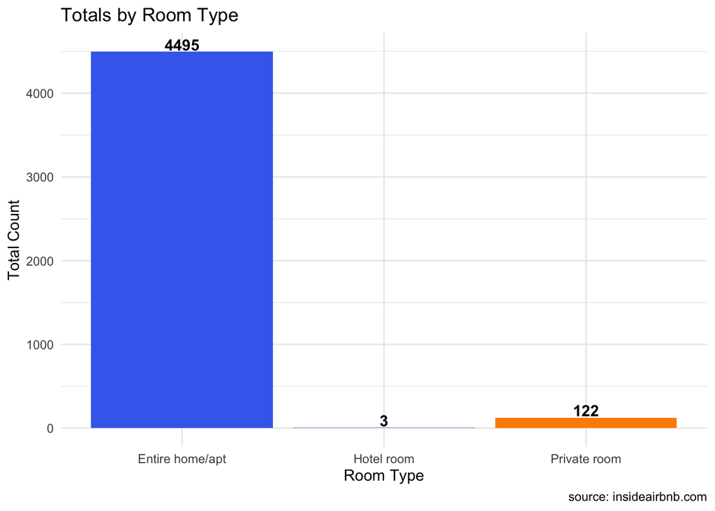

```r
ggplot(san_diego, aes(x = room_type)) +
  geom_bar(fill = c("royalblue2", "purple3", "darkorange")) +
  labs(x = "Room Type",
       y = "Total Count",
       title = "Totals by Room Type",
       caption = "source: insideairbnb.com") +
  geom_text(aes(label = after_stat(count)), stat = "count", vjust = -.15, color = "black", fontface = "bold") +
  theme_minimal()
```

**Number of listings separated by number of bathrooms and bedrooms**

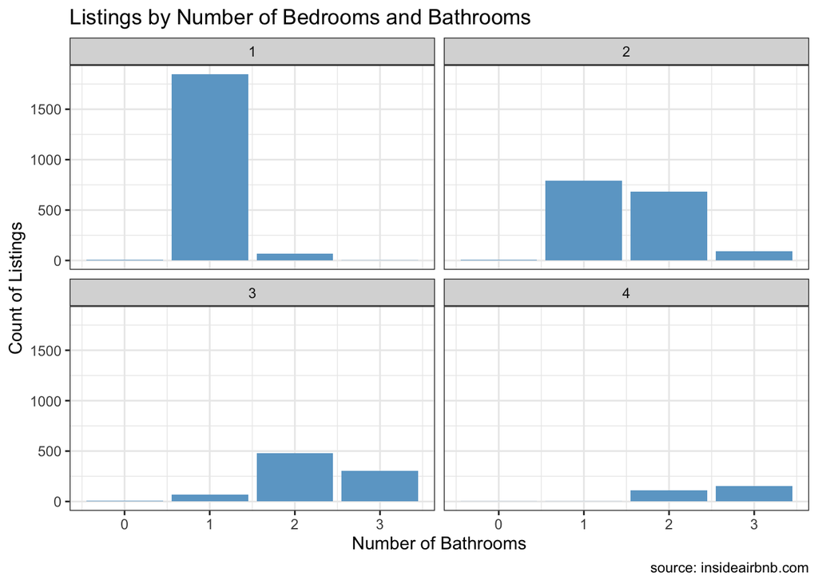

```r
ggplot(san_diego, aes(x = bathrooms)) +
  geom_bar(fill = c("skyblue3")) +
  facet_wrap(vars(bedrooms)) +
  labs(x = "Number of Bathrooms",
       y = "Count of Listings",
       title = "Listings by Number of Bedrooms and Bathrooms",
       caption = "source: insideairbnb.com") +
  theme_bw()
```

**How does the price change as the number of people a listing can accommodate increases?**

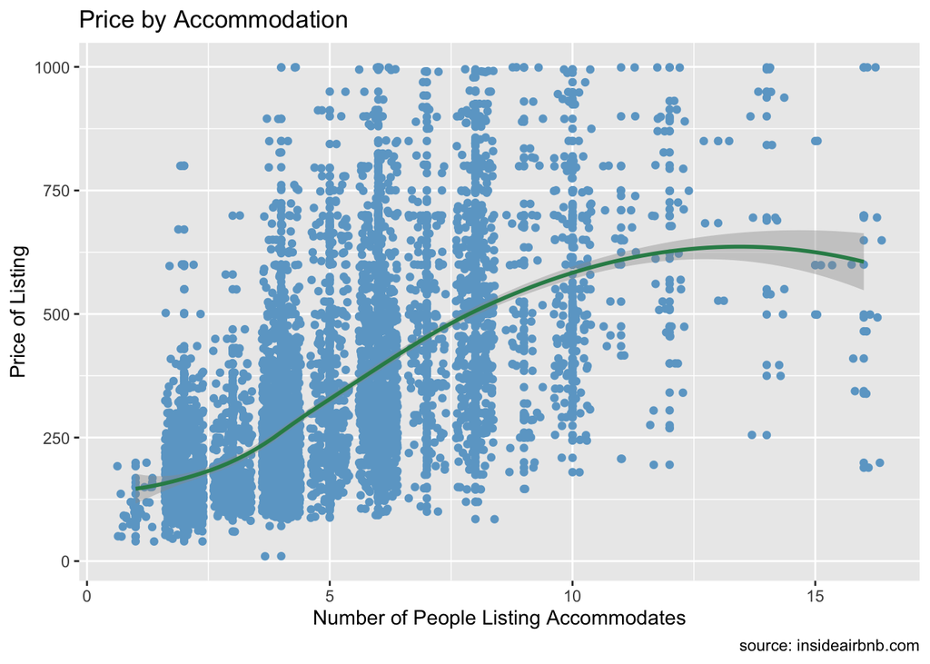

```r
ggplot(san_diego, aes(x = accommodates, y = prices)) +
  geom_point(color = "skyblue3") +
  geom_jitter(color = "skyblue3") +
  geom_smooth(formula = y ~ x, method = "loess", se = TRUE, color = "seagreen4") +
  labs(x = "Number of People Listing Accommodates",
       y = "Price of Listing",
       title = "Price by Accommodation",
       caption = "source: insideairbnb.com") +
  theme_gray()
```

**Look at the price based on the number of bathrooms in a listing.**

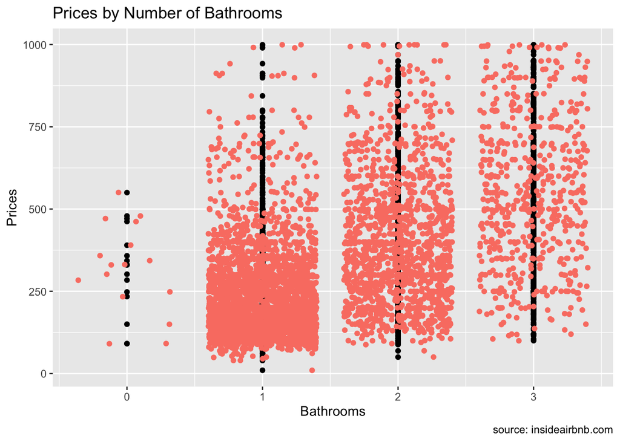

```r
ggplot(san_diego, aes(x = bathrooms, y = prices)) +
  geom_point() +
  geom_jitter(color = "salmon") +
  labs(x = "Bathrooms",
       y = "Prices",
       title = "Prices by Number of Bathrooms",
       caption = "source: insideairbnb.com")
```

**Look at the price based on the number of bedrooms in a listing.**

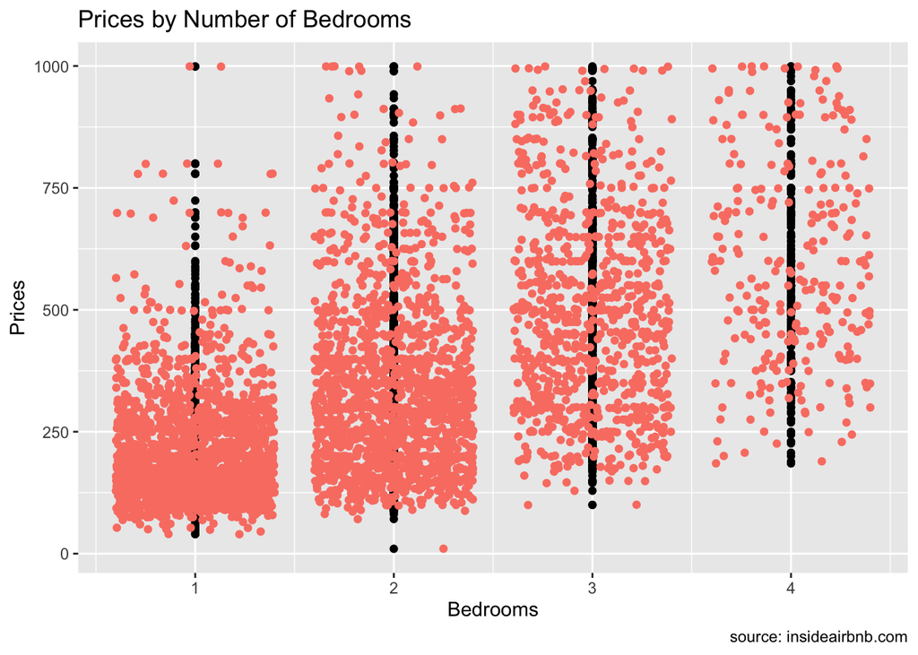

```r
ggplot(san_diego, aes(x = bedrooms, y = prices)) +
  geom_point() +
  geom_jitter(color = "salmon") +
  labs(x = "Bedrooms",
       y = "Prices",
       title = "Prices by Number of Bedrooms",
       caption = "source: insideairbnb.com")
```

```r
#map <- leaflet(san_diego) |>
  #setView(lng = -117.16, lat = 32.72, zoom = 10)

#map <- map |>
  #addMarkers(lng = san_diego$longitude, lat = san_diego$latitude,
             #popup = paste("<b>Neighborhood:<b> ", san_diego$neighborhood,
                           #"<b>Price:<b> ", san_diego$prices))
#map <- map |>
  #addTiles()

#map <- map |>
  #addControl("zoom", position = "topleft") |>
  #addControl("layers", position = "topleft")

#map

#saveWidget(map, file = "san_diego_map.html")
```

# **MODEL**

**Correlation between price and different variables.**

```r
cor(san_diego$prices, san_diego$bedrooms)
```

```
[1] 0.6091046
```

```r
cor(san_diego$prices, san_diego$bathrooms)
```

```
[1] 0.5458176
```

```r
cor(san_diego$prices, san_diego$accommodates)
```

```
[1] 0.6254501
```

**Boxplots**

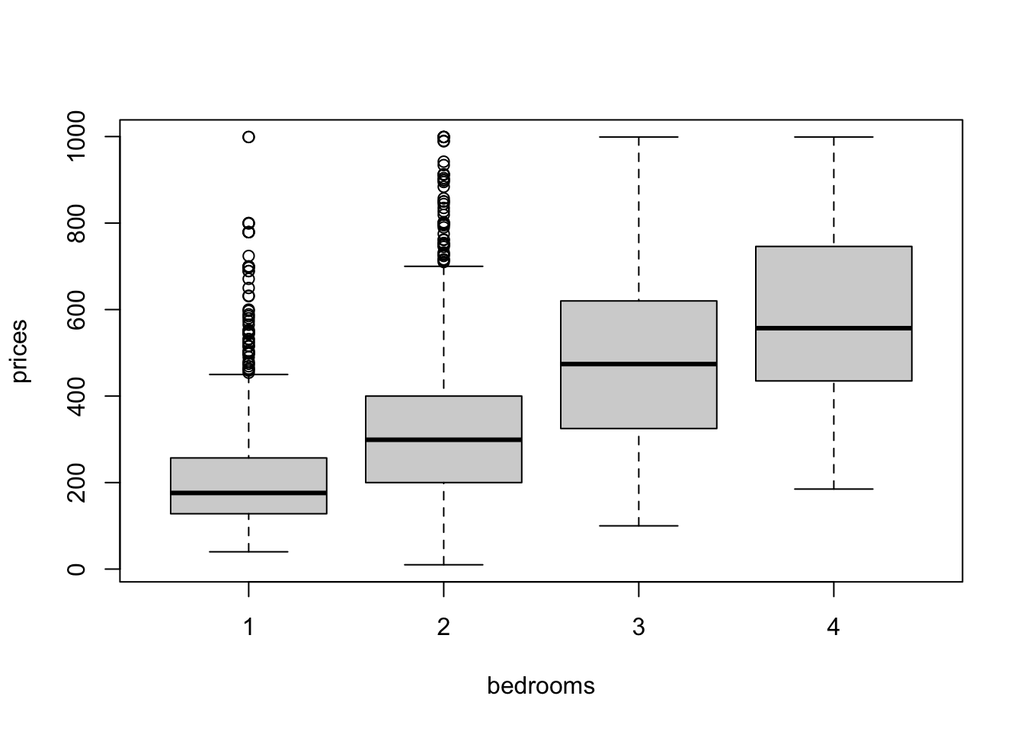

```r
boxplot(prices ~ bedrooms, data = san_diego)
```

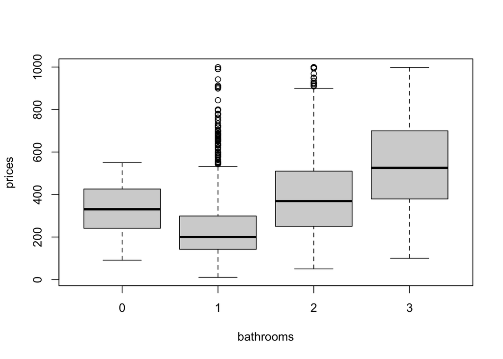

```r
boxplot(prices ~ bathrooms, data = san_diego)
```

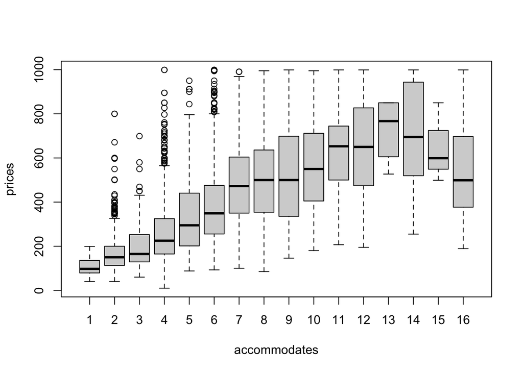

```r
boxplot(prices ~ accommodates, data = san_diego)
```

[figure not shown]

```r
ggplot(san_diego, aes(x = neighborhood, y = prices)) +
  geom_boxplot(color = "darkseagreen") +
  labs(x = "Neighborhood",
       y = "Price",
       title = "Prices by Neighborhoods",
       caption = "source: insideairbnb.com")
```

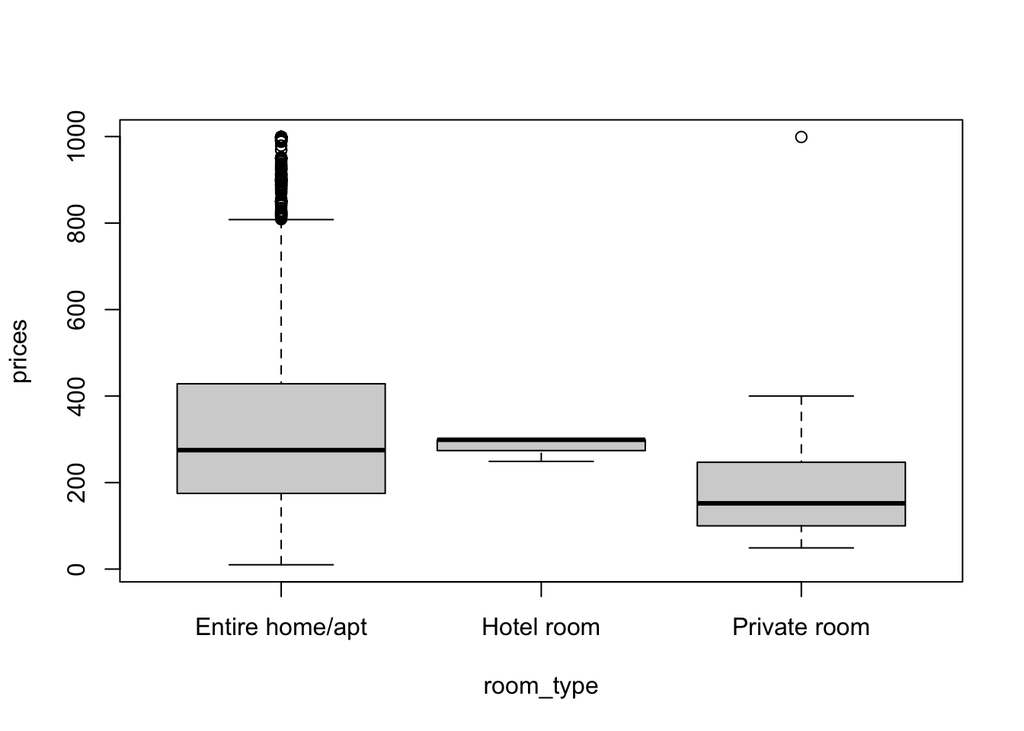

```r
boxplot(prices ~ room_type, data = san_diego)
```

**ANOVA**

```r
sd_price_model <- san_diego |>
  lm(formula = prices ~ bedrooms + bathrooms + accommodates + room_type + neighborhood)

sd_price_model2 <- san_diego |>
  lm(formula = prices ~ neighborhood + bedrooms + bathrooms + accommodates + room_type)

anova(sd_price_model)
```

```
Analysis of Variance Table

Response: prices
               Df   Sum Sq  Mean Sq   F value  Pr(>F)
bedrooms        1 68095537 68095537 3622.6250 < 2e-16 ***
bathrooms       1  4290696  4290696  228.2614 < 2e-16 ***
accommodates    1  8879258  8879258  472.3690 < 2e-16 ***
room_type       2   153067    76534    4.0715 0.01711 *
neighborhood   98 17234625   175864    9.3558 < 2e-16 ***
Residuals    4516 84888566    18797
---
Signif. codes:  0 '***' 0.001 '**' 0.01 '*' 0.05 '.' 0.1 ' ' 1
```

```r
anova(sd_price_model2)
```

```
Analysis of Variance Table

Response: prices
               Df   Sum Sq  Mean Sq   F value  Pr(>F)
neighborhood   98 32619213   332849   17.7073 < 2e-16 ***
bedrooms        1 57487497 57487497 3058.2862 < 2e-16 ***
bathrooms       1  2411003  2411003  128.2633 < 2e-16 ***
accommodates    1  6029072  6029072  320.7415 < 2e-16 ***
room_type       2   106399    53199    2.8302 0.05911 .
Residuals    4516 84888566    18797
---
Signif. codes:  0 '***' 0.001 '**' 0.01 '*' 0.05 '.' 0.1 ' ' 1
```

**Checking Normality assumptions through qqplots and a histogram of residuals**

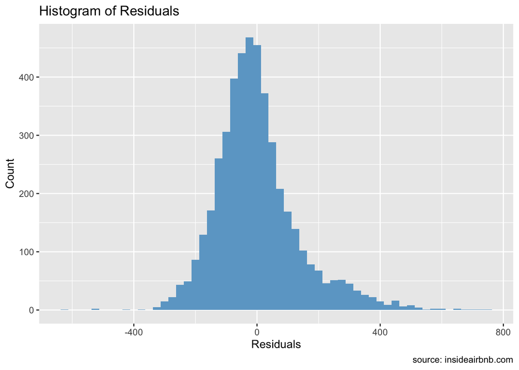

```r
model_residuals <- sd_price_model$residuals

ggplot(sd_price_model, aes(x = model_residuals)) +
  geom_histogram(binwidth = 25, fill = "skyblue3") +
  labs(x = "Residuals",
       y = "Count",
       title = "Histogram of Residuals",
       caption = "source: insideairbnb.com")
```

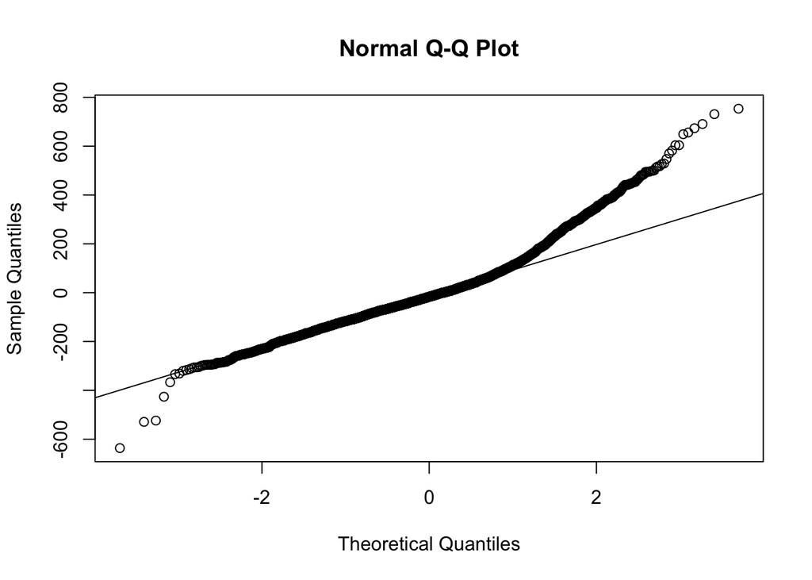

```r
qqnorm(model_residuals)
qqline(model_residuals)
```

**Multiple Linear Regression**

```r
summary(sd_price_model)
```

```
Call:
lm(formula = prices ~ bedrooms + bathrooms + accommodates + room_type +
    neighborhood, data = san_diego)

Residuals:
    Min      1Q  Median      3Q     Max
-636.47  -82.51  -16.54   58.74  753.34

Coefficients:
                                    Estimate Std. Error t value Pr(>|t|)
(Intercept)                          -85.447     79.385  -1.076   0.2818
bedrooms                              53.542      4.401  12.166   <2e-16 ***
bathrooms                             42.304      4.337   9.755   <2e-16 ***
accommodates                          25.890      1.461  17.725   <2e-16 ***
room_typeHotel room                   79.468     80.076   0.992   0.3210
room_typePrivate room                -28.642     13.390  -2.139   0.0325 *
neighborhoodAlta Vista                17.494    112.038   0.156   0.8759
neighborhoodBalboa Park              114.887     80.292   1.431   0.1525
neighborhoodBario Logan               11.633    104.739   0.111   0.9116
neighborhoodBay Ho                    86.619     82.792   1.046   0.2955
neighborhoodBay Park                 100.723     80.972   1.244   0.2136
neighborhoodBay Terrace              -66.523     96.954  -0.686   0.4927
neighborhoodBird Land                  2.265    112.044   0.020   0.9839
neighborhoodBonita Long Canyon        77.086    125.377   0.615   0.5387
neighborhoodCarmel Mountain          -92.749    125.166  -0.741   0.4587
neighborhoodCarmel Valley              5.398     82.945   0.065   0.9481
neighborhoodChollas View              -1.868     96.958  -0.019   0.9846
neighborhoodCity Heights East         47.969     82.502   0.581   0.5610
neighborhoodCity Heights West         43.948     81.096   0.542   0.5879
neighborhoodClairemont Mesa           65.551     81.647   0.803   0.4221
neighborhoodCollege Area              10.495     83.300   0.126   0.8997
neighborhoodColumbia                  91.387     96.981   0.942   0.3461
neighborhoodCore                     148.077     81.013   1.828   0.0676 .
neighborhoodCortez Hill               72.697     81.977   0.887   0.3752
neighborhoodDarnall                   40.037     96.968   0.413   0.6797
neighborhoodDel Cerro                 29.815     96.947   0.308   0.7584
neighborhoodDel Mar Heights          100.403     83.451   1.203   0.2290
neighborhoodEast Lake                -18.961    158.349  -0.120   0.9047
neighborhoodEast Village              88.904     80.081   1.110   0.2670
neighborhoodEastlake Trails           96.962    125.344   0.774   0.4392
```

[output cut: 65 more lines]

```
neighborhoodTierrasanta              157.738    104.749   1.506   0.1322
neighborhoodTijuana River Valley      15.462    158.884   0.097   0.9225
neighborhoodTorrey Pines             171.430     91.424   1.875   0.0608 .
neighborhoodUniversity City           51.130     80.920   0.632   0.5275
neighborhoodValencia Park             -7.242     91.512  -0.079   0.9369
neighborhoodWebster                   66.471     91.405   0.727   0.4671
neighborhoodWest University Heights   75.505     81.007   0.932   0.3513
neighborhoodWooded Area              140.701     84.170   1.672   0.0947 .
neighborhoodYosemite Dr               36.820    158.356   0.233   0.8161
---
Signif. codes:  0 '***' 0.001 '**' 0.01 '*' 0.05 '.' 0.1 ' ' 1

Residual standard error: 137.1 on 4516 degrees of freedom
Multiple R-squared:  0.5375,    Adjusted R-squared:  0.5269
F-statistic: 50.95 on 103 and 4516 DF,  p-value: < 2.2e-16
```

**Price Prediction Based on Multiple Linear Regression Model**

```r
sd_price_model3 <- lm(formula = prices ~ bedrooms + bathrooms + accommodates, data = san_diego)

summary(sd_price_model3)
```

```
Call:
lm(formula = prices ~ bedrooms + bathrooms + accommodates, data = san_diego)

Residuals:
    Min      1Q  Median      3Q     Max
-583.40  -90.77  -26.97   69.02  768.02

Coefficients:
             Estimate Std. Error t value Pr(>|t|)
(Intercept)    15.794      5.620   2.810  0.00497 **
bedrooms       38.794      4.617   8.402  < 2e-16 ***
bathrooms      55.350      4.512  12.266  < 2e-16 ***
accommodates   30.261      1.512  20.019  < 2e-16 ***
---
Signif. codes:  0 '***' 0.001 '**' 0.01 '*' 0.05 '.' 0.1 ' ' 1

Residual standard error: 148.9 on 4616 degrees of freedom
Multiple R-squared:  0.4428,    Adjusted R-squared:  0.4424
F-statistic:  1223 on 3 and 4616 DF,  p-value: < 2.2e-16
```

```r
bedrooms <-  3
bathrooms <- 2
accommodates <- 8

predict(sd_price_model3, data.frame(bedrooms = bedrooms, bathrooms = bathrooms, accommodates = accommodates))
```

```
       1
484.9612
```

# **COMMUNICATE**

In doing this project, I hoped to better understand the different factors that affect the prices of Airbnbs, as well as the different locations in San Diego that are priced higher regardless of the other variables, such as number of bedrooms and bathrooms, how many people the Airbnb can accommodate, and what type of listing it is. I wanted to see what relationships there were between all the variables, and I also wanted to be able to predict the prices of Airbnbs based on these same factors.

Overall, through this project, I was able to understand the different factors that affect the price of Airbnbs, as well as get a better idea of where and what I could purchase to make the most money—based on location and other factors.

# **LIMITATIONS**

Things I’d do differently if I did it again:

1. Probably take the log of my data in order to make it follow a more normal distribution for the ANOVA model.
2. Look into doing a test other than ANOVA due to the fact that some of the factors may not be independent—meaning the number of bedrooms in an Airbnb could affect the number of bathrooms in an Airbnb, for example.
3. Possibly use something other that Linear Regression—for example, maybe logistic regression would give me more accurate predictions than a linear model.